# Violences sur AskMeuf et AskMec

*Document produit le 21/01/2026*

## 1 Rappel du projet

Il s’agit d’étudier les discours portant sur les violences sur AskMec et AskMeuf, à partir d’une base de donnée composées de 10245 posts et leurs 477 705 commentaires. Ce travail s’appuie sur une typologie réalisées lors de mon mémoire de recherche à partir d’une classification de Reinert.

## 2 Élaboration du lexique

Pour récupérer les posts discutant de violences, on s’appuie sur une nouvelle classification de Reinert, réalisée sur le sous-corpus “Relation affectives et sexuelles” issue des posts AskMeuf. Une première classification en trois catégories avait mis en évidence une classe “Problème conjugaux et violence”. Je réalise ici une classification en 6 catégories afin de ne récupérer que les lexique des violences, et m’en inspirer pour retrouver les posts et commentaires traitants des violences. Le lexique des violences apparaît en bleu clair sur l’AFC ci-dessous.

**Voir le code**

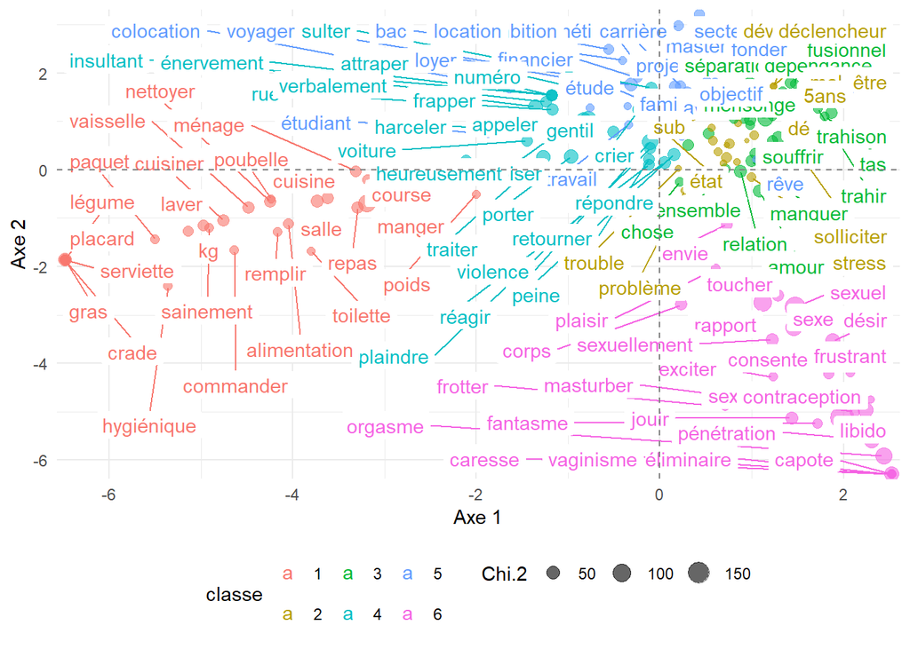

```r
afc <- read_csv2("05_iramuteq/sexe_meuf_corpus_1/Subsexe_meuf_corpus_1_1/sexe_meuf_alceste_1/afc_row.csv")
profile <- read_csv2("05_iramuteq/sexe_meuf_corpus_1/Subsexe_meuf_corpus_1_1/sexe_meuf_alceste_1/profiles.csv")

splits <- profile %>%
  mutate(
    group = cumsum(V2 == "classe")
  ) %>%
  group_split(group)

class1 <- splits[[2]] %>% as.data.frame() %>%
  filter(!is.na(V6))%>%
  mutate(classe = 1)

class2 <- splits[[3]] %>% as.data.frame()%>%
  filter(!is.na(V6))%>%
  mutate(classe = 2)

class3 <- splits[[4]] %>% as.data.frame()%>%
  filter(!is.na(V6)) %>%
  mutate(classe = 3)

class4 <- splits[[5]] %>% as.data.frame() %>%
  filter(!is.na(V6)) %>%
  mutate(classe = 4)

class5 <- splits[[6]] %>% as.data.frame() %>%
  filter(!is.na(V6)) %>%
  mutate(classe = 5)

class6 <- splits[[7]] %>% as.data.frame() %>%
  filter(!is.na(V6)) %>%
  mutate(classe = 6)


class_termes <- bind_rows(class1, class2, class3, class4, class5, class6) %>%
  select(V5, V4, classe) %>%
  group_by(classe) %>%
  slice_head(n = 25) %>%
  ungroup()

colnames(class_termes)[1] <- "termes"
colnames(class_termes)[2] <- "chi.2"
colnames(afc)[1]<- "termes"

replot <- right_join(afc, class_termes, by = "termes")%>%
  mutate(classe = as.character(classe),
         chi.2 = as.numeric(chi.2))


ggplot(replot, aes(x = `Coord. facteur 1`, y = `Coord. facteur 2`, label = termes, color = classe)) +
  geom_point(aes(size = chi.2), alpha = 0.6) +  # Points proportionnels à la contribution
  geom_label_repel(aes(label = termes), label.size = NA, size = 3.8, max.overlaps = 50) +
  geom_hline(yintercept = 0, linetype = "dashed", color = "grey50") +  # Horizontal axis at y = 0
  geom_vline(xintercept = 0, linetype = "dashed", color = "grey50") +# Étiquettes sans chevauchement
  theme_minimal() +
  labs(x = "Axe 1", y = "Axe 2", size = "Chi.2") +
  theme(legend.position = "bottom") +
  scale_x_continuous(expand = expansion(mult = 0.01)) +  # Expand X-axis by 20%
  scale_y_continuous(expand = expansion(mult = 0.01))
```

On peut en extraire les termes contribuant le plus à la classe, ici ce sont les 25 premiers termes. Je ne choisis que de prendre ceux qui se rapproche le plus d’une d’une situation concrète de violences, afin d’éviter au maximum d’avoir des posts sans rapport dans la base.

**Voir le code**

```r
termes_violences <- class4 %>%
  select(V5) %>%
 slice_head(n=25) %>%
  as.list()

termes_violences
```

```
$V5
 [1] "violence"     "appeler"      "gentil"       "frapper"      "porter"
 [6] "traiter"      "crier"        "croiser"      "répondre"     "peine"
[11] "attraper"     "énervement"   "insultant"    "numéro"       "violemment"
[16] "téléphone"    "insulter"     "plaindre"     "rue"          "voiture"
[21] "harceler"     "heureusement" "verbalement"  "réagir"       "retourner"
```

La liste des termes retenu est celle-ci.

**Voir le code**

```r
all_sub2 <- all_sub2 %>%
  mutate(selftext2 = tolower(selftext)) %>%
  mutate(selftext2 = str_replace_all(selftext2, "é|è", "e")) %>%
        mutate( selftext2 = str_replace_all(selftext2, "ee", "e"))

#Test
#sum(str_detect(all_sub2$selftext2, "ée"))

com <- com %>%
  mutate(body2 = str_replace_all(body, "é|è", "e")) %>%
         mutate(body2 = str_replace_all(body2, "ee", "e"))
sex_etc <- all_sub2 %>%
  filter(typo_label == "Relations affectives et sexuelles")


com_sex_etc <- com %>%
  filter(typo_post == "Relations affectives et sexuelles")


#Liste et stat

terms_vector <- c("abus","abusif", "abusive", "accoste","accoster", "attraper",
"agresse","agresser","agression","agression sexuelle",
"attouchement","attouchements", "attouche",
"colere","conjugal", "conjugales", "conjugaux",  "crier","emprise","enervement",
"frappe","frapper",
"harcele","harcelement","harceler","humilier",
"inceste","pedophilie",
"insultant", "insultante", "insulte","insulter","insultes","narcissique", "plainte","poing","police", "temoignage",
"rapport non consenti",
"traiter","tw", "verbalement","victime",
"viol","viole",
"violemment","violence",
"violence", "violente",
"violences", "violent", "violente",
"violentometre","violer" )

term <- paste0("\\b", terms_vector, "\\b", collapse = "|")

terms_vector %>%
  sort()
```

```
 [1] "abus"                 "abusif"               "abusive"
 [4] "accoste"              "accoster"             "agresse"
 [7] "agresser"             "agression"            "agression sexuelle"
[10] "attouche"             "attouchement"         "attouchements"
[13] "attraper"             "colere"               "conjugal"
[16] "conjugales"           "conjugaux"            "crier"
[19] "emprise"              "enervement"           "frappe"
[22] "frapper"              "harcele"              "harcelement"
[25] "harceler"             "humilier"             "inceste"
[28] "insultant"            "insultante"           "insulte"
[31] "insulter"             "insultes"             "narcissique"
[34] "pedophilie"           "plainte"              "poing"
[37] "police"               "rapport non consenti" "temoignage"
[40] "traiter"              "tw"                   "verbalement"
[43] "victime"              "viol"                 "viole"
[46] "violemment"           "violence"             "violence"
[49] "violences"            "violent"              "violente"
[52] "violente"             "violentometre"        "violer"
```

### 2.1 Lexique “violences” dans les posts

On peut ensuite compter le nombre d’occurences ainsi que le nombre de posts qui contiennent ces termes. Un travail à refaire, parce que j’ai un bug avec les package d’analyse textuelle que je suis entrain de régler. Pour l’instant, c’est du bricolage, mais les effectif ne devrait pas changer beaucoup.

**Voir le code**

```r
# Get French stems for grouping
stem_groups <- wordStem(terms_vector, language = "french")
stem_groups <- ifelse(stem_groups == "", terms_vector, stem_groups)

# Create a list where each group contains its terms
grouped_terms <- split(terms_vector, stem_groups)

# Function to count documents containing ANY term from a group
count_docs_with_term_group <- function(texts, term_group) {
  # Create pattern for all terms in the group
  pattern <- paste0("\\b", term_group, "\\b", collapse = "|")
  sum(str_detect(texts, regex(pattern, ignore_case = TRUE)))
}

# Function to count TOTAL OCCURRENCES of terms from a group
count_total_occurrences <- function(texts, term_group) {
  # Create a pattern for all terms in the group
  pattern <- paste0("\\b", term_group, "\\b", collapse = "|")

  # Count ALL occurrences (not just documents)
  total_count <- sum(str_count(texts, regex(pattern, ignore_case = TRUE)))

  return(total_count)
}

# Count for posts
nb_post_relation <- sapply(grouped_terms, function(terms) {
  count_docs_with_term_group(sex_etc$selftext2, terms)
})

occu_post_relation <- total_post_occurrences <- sapply(grouped_terms, function(terms) {
  count_total_occurrences(sex_etc$selftext2, terms)
})

nb_post_allbase <- sapply(grouped_terms, function(terms) {
  count_docs_with_term_group(all_sub2$selftext2, terms)
})

nb_occu_post_allbase <- total_post_occurrences <- sapply(grouped_terms, function(terms) {
  count_total_occurrences(all_sub2$selftext2, terms)
})

# Count for comments
nb_com <- sapply(grouped_terms, function(terms) {
  count_docs_with_term_group(com_sex_etc$body2, terms)
})

# Create final dataframe
stat_post <- data.frame(
  term_group = names(grouped_terms),
  terms = sapply(grouped_terms, paste, collapse = ", "),
  nb_post_relation = nb_post_relation,
  occu_post_relation = occu_post_relation,
  nb_post_allbase = nb_post_allbase,
  nb_occu_post_allbase = nb_occu_post_allbase,
  stringsAsFactors = FALSE
) %>%
  mutate(
    post_relation_term_perc = round(nb_post_relation / nrow(sex_etc) * 100, 2),
    occu_relation_perc = round(occu_post_relation / nrow(sex_etc) * 100, 2),
    post_all_term_perc = round(nb_post_allbase / nrow(all_sub2) * 100, 2),
    occu_relation_perc = round(nb_occu_post_allbase / nrow(all_sub2) * 100, 2),
  ) %>% arrange(desc(nb_post_relation))

dt <- datatable(stat_post,
                options = list(
    pageLength = 10,           # Show 15 rows per page
    scrollX = TRUE,            # Horizontal scroll if needed
    scrollY = "400px"         # Fixed height with vertical scroll
  ),
  class = 'display compact',   # Compact styling
  rownames = FALSE             # Hide row numbers
)

dt
```

| term_group | terms | nb_post_relation | occu_post_relation | nb_post_allbase | nb_occu_post_allbase | post_relation_term_perc | occu_relation_perc | post_all_term_perc |
| --- | --- | --- | --- | --- | --- | --- | --- | --- |
| coler | colere | 96 | 119 | 130 | 164 | 2.22 | 1.6 | 1.27 |
| insult | insultant, insultante, insulte, insulter, insultes | 88 | 103 | 153 | 180 | 2.04 | 1.76 | 1.49 |
| violent | violemment, violente, violent, violente | 81 | 98 | 131 | 159 | 1.88 | 1.55 | 1.28 |
| harcel | harcele, harcelement, harceler | 80 | 101 | 158 | 209 | 1.85 | 2.04 | 1.54 |
| violenc | violence, violence, violences | 77 | 118 | 169 | 272 | 1.78 | 2.65 | 1.65 |
| viol | viol, viole, violer | 70 | 104 | 109 | 166 | 1.62 | 1.62 | 1.06 |
| agress | agresse, agresser, agression | 68 | 109 | 126 | 189 | 1.57 | 1.84 | 1.23 |
| abus | abus, abusif, abusive | 53 | 66 | 78 | 93 | 1.23 | 0.91 | 0.76 |
| tw | tw | 48 | 53 | 57 | 62 | 1.11 | 0.61 | 0.56 |
| plaint | plainte | 40 | 83 | 56 | 104 | 0.93 | 1.02 | 0.55 |

[output cut: 21 more lines]

### 2.2 Lexique “violences” dans les commentaires

On fait la même chose pour les commentaires, en retirant certains termes trop communs (Traiter, porter, police, verbalement..). Ci-dessous, le comptes d’occurences et de commentaires.

**Voir le code**

```r
terms_vector_com <- c(
  "viol", "viole", "agresse", "frappe", "abus",
  "violences conjugales", "agression", "agression sexuelle", "agresser", "violences", "violence", "violent",
  "tw", "victime", "abusif", "violer", "attouchement", "attouchements", "humilier",
  "inceste", "emprise", "violence", "pedophilie", "crier", "insulter", "insultant", "plainte",
  "harcelement", "harcele", "harceler", "accoste", "accoster", "rapport non consenti", "narcissique",
  "violences psychologiques", "violence psychologique",  "insulte", "insultes", "violentometre", "colère", "conjugal", "enervement", "violemment", "frapper", "frape"
) %>% sort()

# Add word boundaries to all terms
term_com <- paste0("\\b", terms_vector_com, "\\b", collapse = "|")


# Get French stems for grouping
stem_groups <- wordStem(terms_vector_com, language = "french")
stem_groups <- ifelse(stem_groups == "", term_vector_com, stem_groups)

# Create a list where each group contains its terms
grouped_terms <- split(terms_vector_com, stem_groups)

# Function to count documents containing ANY term from a group
count_docs_with_term_group <- function(texts, term_group) {
  # Create pattern for all terms in the group
  pattern <- paste0("\\b", term_group, "\\b", collapse = "|")
  sum(str_detect(texts, regex(pattern, ignore_case = TRUE)))
}



# Count for coms
nb_com_relation <- sapply(grouped_terms, function(terms) {
  count_docs_with_term_group(com_sex_etc$body2, terms)
})

occu_com_relation <- total_com_occurrences <- sapply(grouped_terms, function(terms) {
  count_total_occurrences(com_sex_etc$body2, terms)
})

nb_com_allbase <- sapply(grouped_terms, function(terms) {
  count_docs_with_term_group(com$body2, terms)
})

nb_occu_com_allbase <- total_com_occurrences <- sapply(grouped_terms, function(terms) {
  count_total_occurrences(com$body2, terms)
})

# Create final dataframe
stat_com <- data.frame(
  term_group = names(grouped_terms),
  terms = sapply(grouped_terms, paste, collapse = ", "),
  nb_com_relation = nb_com_relation,
  occu_com_relation = occu_com_relation,
  nb_com_allbase = nb_com_allbase,
  nb_occu_com_allbase = nb_occu_com_allbase,
  stringsAsFactors = FALSE
) %>%
  mutate(
    com_relation_term_perc = round(nb_com_relation / nrow(com_sex_etc) * 100, 2),
    occu_relation_perc = round(occu_com_relation / nrow(com_sex_etc) * 100, 2),
    com_all_term_perc = round(nb_com_allbase / nrow(com) * 100, 2),
    occu_relation_perc = round(nb_occu_com_allbase / nrow(com) * 100, 2),
  ) %>% arrange(desc(nb_com_relation))

dt <- datatable(stat_com,
                options = list(
    pageLength = 10,           # Show 15 rows per page
    scrollX = TRUE,            # Horizontal scroll if needed
    scrollY = "400px"         # Fixed height with vertical scroll
  ),
  class = 'display compact',   # Compact styling
  rownames = FALSE             # Hide row numbers
)

dt
```

| term_group | terms | nb_com_relation | occu_com_relation | nb_com_allbase | nb_occu_com_allbase | com_relation_term_perc | occu_relation_perc | com_all_term_perc |
| --- | --- | --- | --- | --- | --- | --- | --- | --- |
| violenc | violence, violence, violences | 1523 | 1974 | 4375 | 5944 | 0.89 | 1.24 | 0.92 |
| insult | insultant, insulte, insulter, insultes | 1282 | 1600 | 3627 | 4538 | 0.75 | 0.95 | 0.76 |
| viol | viol, viole, violer | 1220 | 1728 | 3111 | 4257 | 0.71 | 0.89 | 0.65 |
| agress | agresse, agresser, agression | 1084 | 1349 | 2897 | 3580 | 0.63 | 0.75 | 0.61 |
| harcel | harcele, harcelement, harceler | 1050 | 1231 | 3085 | 3717 | 0.61 | 0.78 | 0.65 |
| victim | victime | 937 | 1153 | 2258 | 2769 | 0.55 | 0.58 | 0.47 |
| violent | violemment, violent | 797 | 877 | 1934 | 2100 | 0.46 | 0.44 | 0.4 |
| plaint | plainte | 713 | 899 | 1309 | 1651 | 0.42 | 0.35 | 0.27 |
| abus | abus, abusif | 459 | 514 | 1047 | 1167 | 0.27 | 0.24 | 0.22 |
| frapp | frappe, frapper | 373 | 421 | 1050 | 1203 | 0.22 | 0.25 | 0.22 |

[output cut: 19 more lines]

## 3 Création des bases de données

On peut donc créer deux bases de données : celles avec les posts contenant les termes choisis, celui avec les commentaires contenant les termes. On ne recherche que dans les posts classé “Relation Affectives et sexuelles” pour limiter le bruit. Ci-dessous, 10 posts tirés aléatoirement et le mot qui a causé leur inclusion dans la base de donnée.

**Voir le code**

```r
vss_post_plus <- all_sub2 %>%
  filter(typo_label == "Relations affectives et sexuelles") %>%
  filter(str_detect(selftext2, regex(term, ignore_case = TRUE))) %>%
  mutate(
    matches = str_extract_all(selftext2, regex(term, ignore_case = TRUE)),
    flag = map_chr(matches, ~paste(unique(.x), collapse = ", "))
  ) %>%
  select(-matches)

nb_post <- nrow(vss_post_plus)

test <- vss_post_plus %>%
  sample_n(10) %>%
  select(selftext2, flag)


dt <- datatable(test,
                options = list(
    pageLength = 5,           # Show 15 rows per page
    scrollX = TRUE,            # Horizontal scroll if needed
    scrollY = "400px"         # Fixed height with vertical scroll
  ),
  class = 'display compact',   # Compact styling
  rownames = FALSE             # Hide row numbers
)

dt
```

| selftext2 | flag |
| --- | --- |
| faire son deuil...? (f19 si cette info sert) je vais être bref ça va bientôt faire 3 mois mai- bientôt août que il m as quitte. la relation a dure 3 mois egalement. la douleur s intensifie au lieu de … | harcelement |
| comment est fier de soi sans se sentir narcissique ou vantard, alors qu on ne l est pas ? salut à tous commençons par les nouvelles. j ai recemment decide de faire une croix sur mes anciens potes que … | narcissique |
| je me veux d avoir cru un c****. que feriez vous pour calmer votre colere contre vous/contre lui ? j ai pas une grande experience des hommes et je m en veux beaucoup d avoir cru un homme marie qu il e… | colere |
| suis-je une hypocrite ? salut, j ai 21 ans et je suis l aine de ma fratrie. à l ecole j ai toujours eu des bonnes notes et dans toutes les ecoles où j ai ete (j ai demenage plusieurs fois et j ai chan… | attouchements |
| je l aime, alors pourquoi j en ressens du negatif ? bonjour à tous, j ai 24 ans et je suis en couple depuis bientôt 6 mois. honnêtement, ce n est pas dans mes habitudes de poster ce genre de choses, m… | verbalement |
| comment oublier mon crush? je connais mon beguin depuis 3 ans, j ai connu des hommes mais c est le seul qui jusqu à present m a fait ressentir les sentiments que je ressens actuellement pour lui. nous… | colere |
| comment se comporter avec une proche coince dans une relation toxique? j ai rapidement parle de la situation de ma ssur sur des commentaires et ça m a pousse à beaucoup reflechir, j aimerai avoir des … | abusive, emprise |
| premiere fois ou premier rapport ? il y a 12 ans, j ai ete victime de viol par un "pote" que j ai heberge, et c etait mon premier rapport sexuel. presque 3 ans apres je tombe amoureuse et me mets en c… | victime, viol |
| j ai tout foire ? salut tout le monde, bon je previens tout de suite, ça va être long, et complique, j ai besoin de bien expliquer la situation sinon l histoire vas être, je pense, fausse. en gros qua… | harceler, insulte, violent |
| comment expliquer à un papa boomer que suçon =/= marque de violence? bonjour j ai 18 ans, je sors avec un homme de 22 ans depuis quelques semaines et on est actifs sexuellement parlant. mon copain est… | violence, crier |

On obtient donc une base de données de 587 posts. On applique la même méthode aux commentaires, en supprimant les commentaires de l’équipe de modérations qui contiennent souvent le mot “insultes”. Ci-dessous, 10 commentaires tirés aléatoirement et le mot qui a causé leur inclusion dans la base de donnée.

**Voir le code**

```r
vss_com_plus <- com %>%
  filter(author != "AskMec-ModTeam" & author != "AskMec-ModTeam" ) %>%
  filter(typo_post == "Relations affectives et sexuelles" ) %>%
  filter(str_detect(body2, regex(term_com, ignore_case = TRUE))) %>%
  mutate(
    matches = str_extract_all(body2, regex(term_com, ignore_case = TRUE)),
    flag = map_chr(matches, ~paste(unique(.x), collapse = ", "))
  ) %>%
  select(-matches)

com_grouped <- vss_com_plus %>%
  group_by(clé) %>%
  summarise(count = n()) %>%
  arrange(desc(count))

com_grouped_sup3 <- com_grouped %>%
  filter(count > 3)


test2 <- vss_com_plus %>%
  sample_n(10) %>%
  select(body2, flag)

dt <- datatable(test2,
                options = list(
    pageLength = 5,           # Show 15 rows per page
    scrollX = TRUE,            # Horizontal scroll if needed
    scrollY = "400px"         # Fixed height with vertical scroll
  ),
  class = 'display compact',   # Compact styling
  rownames = FALSE             # Hide row numbers
)

dt
```

| body2 | flag |
| --- | --- |
| &amp;gt;Sauf qu'elle etait dejà en couple. Malgre ça, on a fini par avoir des rendez-vous secrets et coucher ensemble, y compris dans l'appartement qu'elle partage avec son copain. Un veritable abus d… | abus |
| Mec ici donc prend le conseil comme tu veux.''Je trouve sa reaction ultra disproportionne. Ça me rappelle les pires côtes de mon pere qui malgre le fait qu'il n'ait jamais leve la main sur ma mere ou … | frapper |
| Si ton mec est sur le spectre autistique c'est possible qu'il n'ait sincerement aucune ide de quand c'est ok de t'embrasser ou pas. Imagine-toi à sa place: il y a quelqu'un que tu aimes, que tu ne veu… | agression |
| Je suis contre le harcelement, je ne drague pas dans la rue. Tous les hommes ne sont pas irrespectueux, c'est une tres petite minorite. Vous voulez être respecter mesdames, arrangez vous pour qu'on pu… | harcelement, harceler |
| Je connais quelqu'un qui a eu plus ou moins le même genre d'histoire avec une collegue, du jour au lendemain elle lui a mis sur le dos du harcelement sexuel, à mediter&amp; | harcelement |
| Personnellement, quand tu parles de ça, ça me fait penser à toutes ces personnes à problemes qui un jour ont fait du mal autour d'elles (au point de du coup finir "celebre"). Je ne veux pas forcement … | violent |
| Moi j'ai la belle mere ambiance faux derche je me fais passer pour la victime. Desole pour toi...il paraît que quand on se marie ça cre ensuite un tri, ici ça a clairement ete le cas, des choses sont … | victime |
| et alors ? si elle s'est sentie assez en confiance avec lui pour dormir avec lui sans avoir peur de se faire violer, je pense justement que ça joue en sa faveur et qu'elle a confiance en lui. puis vot… | violer |
| Tu as parfaitement le droit de te sentir mal à l'aise, c'etait effectivement une agression sexuelle. La reaction des mecs autour est sexiste, ce serait l'inverse tout le monde aurait ete scandalise. C… | agression |
| Parler de culture de la pedophilie c'est traiter les gens de pedophiles, et tu dis clairement qu'un homme qui n'aime pas les poils est un pedophile.''Oui je me sens vise car j'ai horreur des poils, qu… | pedophilie |

On obtient ainsi une base de données de 8073 commentaires, répondant à 1778 posts.

### 3.1 Base de donnée étendue

**Voir le code**

```r
vss_com_plus_top <- vss_com_plus %>%
  group_by(clé) %>%
  arrange(desc(score)) %>%  # Sort by score descending (highest first)
  slice(1) %>%  # Take only the first (highest score) for each post
  ungroup()

post_plusplus <- all_sub2 %>%
  filter(links %in% com_grouped_sup3$clé) %>%
  filter(links %nin% vss_post_plus$links) %>%
  mutate(com_scoremax = vss_com_plus_top$body[match(links, vss_com_plus_top$clé)],
         flag_com = vss_com_plus_top$flag[match(links, vss_com_plus_top$clé)],
         score_com = vss_com_plus_top$score[match(links, vss_com_plus_top$clé)])


post_plus_test <-  post_plusplus %>%
  sample_n(10) %>%
  select(selftext, com_scoremax,flag_com)

dt <- datatable(post_plus_test,
                options = list(
    pageLength = 5,           # Show 15 rows per page
    scrollX = TRUE,            # Horizontal scroll if needed
    scrollY = "400px"         # Fixed height with vertical scroll
  ),
  class = 'display compact',   # Compact styling
  rownames = FALSE             # Hide row numbers
)

dt
```

| selftext | com_scoremax | flag_com |
| --- | --- | --- |
| est ce que j exagère en réagissant de cette façon ? salut tout le monde, un peu de background: je suis en couple depuis bientôt 9 ans avec la personne la plus sincère de france (voir même le monde). j… | Si c'était en rigolant j'aurais pas mal pris. C'était vraiment sa façon de dire, surtout le fait qu'elle s'est pas adressée à moi, mais plutôt à sa mère. Je sais encaisser des insultes et remarques, m… | insultes |
| comment vous auriez réagi? bonjour, je voulais juste raconter un truc qui vient de se passer et qui m a gêné. je me permets de raconter parce que j ai vu un poste similaire il y a quelques jours. pour… | Je suis vraiment désolée pour ce que tu viens de subir, encore plus désolée que ce ne soit pas la première fois et vraiment navrée que tu ne vois pas la gravité de la chose.'''Je comprends que tu l'ai… | violence, viol |
| je ne sais pas quoi faire ? bonjour, je perds petit à petit confiance en ma copine. tout ce qu elle fait me laisse présager que si je ne suis pas là elle pourrait se faire tripoter voir pire parce qu … | En fait c'est elle la victime ici donc oui tu t'en prends a la personne qui l'agresse pas à elle et oui s'en prendre à la victime c'est valider la culture du viol donc du sexisme. ''Certes ce serait b… | victime, agresse, viol, agression |
| 3mois sans trop d intimité en début de relations ? hello guys! , on s est rencontré sur une appli avec ma copine (h34) et (f38) (pas d enfant) et cela fait presque 3mois que nous sommes ensemble, on d… | Bah non ça ne s'appelle pas du viol conjugal. Quand on discute et on communique avec sa/son partenaire et qu'on se rend compte qu'on a pas la même libido, on arrive souvent a trouver un compromis. Y'a… | viol, conjugal |
| est-ce que vous aussi votre ex, elle devient... exécrable quand vous vous êtes séparé ? pour le contexte, il y a 2/3 mois, on s est séparé avec mon ex suite à une relation de 3 ans ensemble. on s est … | Mdrrrr je ne met pas mes chaussettes sur le canapé donc ça va ! ''Mais oui je vois totalement ce que tu veux dire. La chose est qu'on a tout emmagasiner chacun de son côté sans vraiment en parler ''On… | violent |
| quels étaient les motifs de vos ruptures ? salut ! dans l optique d éviter les pièges courants qui amènent un couple à se séparer, j aimerais savoir quels ont été les motifs de vos ruptures / divorces… | Première relation pour moi, 16 ans. Avec une meuf super toxique mais je m'en rendais pas trop compte. Je voyais ses humiliations, ses insultes et sa violence physique sur moi comme "normales". Et puis… | insultes, violence |
| obsession qui dure depuis 3 ans : comment faire ? coucou, f24 ici il y a un peu plus de 3 ans il y avait une fille qui bossait dans un magasin durant l été. elle y travaillait juste pendant les vacanc… | TROIS ANS D'OBSESSION c'est un psy qu'il faut aller voir, c'est probablement de l'érotomanie, il faut en soigner avant que ça dégénère.''Et tu lui demandes d'envoyer un message ? Elle a besoin d'aide … | harceler |
| il me trompe que faire? il me trompe avec une de mes amie j ai un copain depuis 6 ans, il est attentionné prend soin moi calme( aux contraire de moi &gt;#&gt;#) nous avons un enfants depuis 2 1/2 . il… | C'est très grave de te donner des somnifères à ton insu, qui sait ce qu'il a pu faire dans ton sommeil ? Ce type est dangereux, tu dois te sortir de là. ''Pour commencer tu peux raconter tout ça à un … | plainte |
| pourquoi mon ex viendrait chez moi faire le ménage ? alors bon, euh, je suis un échec comme adulte. j essaie de changer. en gros, je suis crade. je fais le ménage que quand c est plus sale que je peux… | C'est bien hypocrite de débarquer ici en mode "Je ne sais pas comment lui faire arrêter" alors qu'il te suffit de récupérer tes clés. Tu profites de la situation et des sentiments de ton ex, et tu vie… | insultant |
| pires messages de mecs ? hello, c est encore moi, la meuf qui a créé le post sur la prépondérance des posts de mecs ! dans les commentaires, on m a fait remarquer (à raison) que plus de mecs sur reddi… | J'ai reçu un charmant ' est ce que tu es en train de mouiller ta petite culotte ?' de la part d'un camarade de classe au collège. J'avais 13 ans et venais de lui dire que je regardais une romcom (avec… | violent |

Sans compter ceux qui sont déjà inclus dans le premier df, c’est 336 posts que nous pouvons ajouter à la base.

**Voir le code**

```r
post_vss <- all_sub2 %>%
  filter(links %in% vss_post_plus$links | links %in% post_plusplus$links)%>%
  mutate(prov = ifelse(links %in% vss_post_plus & links %nin% post_plusplus$links, "post",
                       "com")) %>%
  mutate(flag = case_when(prov == 'post' ~ vss_post_plus$flag[match(links,vss_post_plus$links )],
                          prov == 'com' ~ "com flag"),
         flag_com = case_when(prov == 'com' ~ post_plusplus$flag_com[match(links, post_plusplus$links)]),
         com_max = ifelse(prov == "com",
                          post_plusplus$com_scoremax[match(links, post_plusplus$links)],
                          "post_flag"))




post_vss <- all_sub2 %>%
  filter(links %in% vss_post_plus$links | links %in% post_plusplus$links) %>%
  mutate(
    prov = ifelse(links %in% vss_post_plus$links & links %nin% post_plusplus$links, "post", "com"),
    flag = case_when(
      prov == 'post' ~ vss_post_plus$flag[match(links, vss_post_plus$links)],
      prov == 'com' ~ "com flag"
    ),
    flag_com = case_when(
      prov == 'com' ~ post_plusplus$flag_com[match(links, post_plusplus$links)],
      prov == 'post' ~ "post_flag"  # Explicitly set to NA for post rows
    ),
    com_max = ifelse(
      prov == "com",
      post_plusplus$com_scoremax[match(links, post_plusplus$links)],
      "post_flag"
    )
  )

com_post_vss <- com %>%
  filter(clé %in% post_vss$links)
```

En fusionnant les deux base de données, on a donc 923 posts traitants des violences, et si on récupère l’ensemble des commentaires de tout ces posts (qui peuvent donc ne pas contenir de termes sur les violences), on obtient 61807 commentaires.

## 4 Statistiques descriptives

On peut maintenant commencer à faire des statistiques descriptives :

- Sur les posts contenants le lexique

**Voir le code**

```r
lul <- make_cross_table(
  vss_post_plus, genre2, subreddit,
  percent = "cell",
  label = list(genre2 ~ "Genre", subreddit ~ "Subreddit"),
  filename = NULL
)

lul
```

|  | Subreddit AskMec | Subreddit AskMeuf | Total |
| --- | --- | --- | --- |
| Genre |  |  |  |
| Femme | 33 (5.6%) | 298 (51%) | 331 (56%) |
| Homme | 62 (11%) | 145 (25%) | 207 (35%) |
| Unknown | 5 (0.9%) | 44 (7.5%) | 49 (8.3%) |
| Total | 100 (17%) | 487 (83%) | 587 (100%) |

Test du khi-deux : p < 0.001

- Sur les posts de la base étendue

**Voir le code**

```r
lul <- make_cross_table(
  post_vss, genre2, subreddit,
  percent = "cell",
  label = list(genre2 ~ "Genre", subreddit ~ "Subreddit"),
  filename = NULL)

lul
```

|  | Subreddit AskMec | Subreddit AskMeuf | Total |
| --- | --- | --- | --- |
| Genre |  |  |  |
| Femme | 90 (9.8%) | 406 (44%) | 496 (54%) |
| Homme | 132 (14%) | 221 (24%) | 353 (38%) |
| Unknown | 11 (1.2%) | 63 (6.8%) | 74 (8.0%) |
| Total | 233 (25%) | 690 (75%) | 923 (100%) |

Test du khi-deux : p < 0.001

Il y a énormément d’hommes. Soit un problème de méthodo, soit les lexiques sont les mêmes pour des faits différents.

On peut faire la même chose pour les commentaires :

- Sur les commentaires contenant un terme lexique

**Voir le code**

```r
#Stricte

lul <- make_cross_table(
  vss_com_plus, genre2, subreddit,
  percent = "cell",
  label = list(genre2 ~ "Genre", subreddit ~ "Subreddit"),
  filename = NULL)

lul
```

|  | Subreddit AskMec | Subreddit AskMeuf | Total |
| --- | --- | --- | --- |
| Genre |  |  |  |
| Femme | 619 (7.7%) | 4,213 (52%) | 4,832 (60%) |
| Homme | 1,964 (24%) | 1,154 (14%) | 3,118 (39%) |
| Unknown | 7 (<0.1%) | 116 (1.4%) | 123 (1.5%) |
| Total | 2,590 (32%) | 5,483 (68%) | 8,073 (100%) |

Test du khi-deux : p < 0.001

- Sur l’ensemble des commentaires répondant à un post de la base étendue

**Voir le code**

```r
lul <- make_cross_table(
  com_post_vss, genre2, subreddit,
  percent = "cell",
  label = list(genre2 ~ "Genre", subreddit ~ "Subreddit"),
  filename = NULL)

lul
```

|  | Subreddit AskMec | Subreddit AskMeuf | Total |
| --- | --- | --- | --- |
| Genre |  |  |  |
| Femme | 5,747 (9.3%) | 24,169 (39%) | 29,916 (48%) |
| Homme | 20,923 (34%) | 10,116 (16%) | 31,039 (50%) |
| Unknown | 82 (0.1%) | 770 (1.2%) | 852 (1.4%) |
| Total | 26,752 (43%) | 35,055 (57%) | 61,807 (100%) |

Test du khi-deux : p < 0.001

On peut également comparer la répartition de genre des auteurices de posts de la base étendue en fonction de la provenance du post : utilisation du lexique dans le post même où récupéré à travers les commentaires ?

**Voir le code**

```r
lul <- make_cross_table(
  post_vss, genre2, prov,
  percent = "row",
  label = list(genre2 ~ "Genre", prov ~ "Provenance"),
  filename = NULL)

lul
```

|  | Provenance com | Provenance post | Total |
| --- | --- | --- | --- |
| Genre |  |  |  |
| Femme | 165 (33%) | 331 (67%) | 496 (100%) |
| Homme | 146 (41%) | 207 (59%) | 353 (100%) |
| Unknown | 25 (34%) | 49 (66%) | 74 (100%) |
| Total | 336 (36%) | 587 (64%) | 923 (100%) |

Test du khi-deux : p = 0.019

## 5 Répartition de genre des termes du lexique

Il y a une grande proportions d’hommes. Pour expliquer ce phénomène, on peut essayer de représenter la part d’homme et de femmes qui emploient chaque termes du lexique étudié. Pour faciliter la lisibilité, j’ai regroupé certains termes, le détail est disponible en déroulant le code.

**Voir le code**

```r
#On groupe les mots flag avec les racines
vss_post_plus <- vss_post_plus %>%
  mutate(flag_group = wordStem(flag, language = "french")) %>%
  mutate(flag_group2 = case_when(str_detect(flag, "accoste|accoster")  ~ "accost",
                                 str_detect(flag, "attraper|attrape" )~ "attrape",
                                 str_detect(flag, "agresse|agresser|agression" )~ "agress",
                                 str_detect(flag, "attouchement|attouchements" )~ "attouchement",
                                 str_detect(flag, "colere|crier|enervement" )~ "colère/cri/nrv",
                                 str_detect(flag, "frappe|frapper" )~  "frappe",
                                 str_detect(flag, "harcele|harcelement|harceler" )~ "harcel",
                                 str_detect(flag, "inceste|pedophilie" )~ "inceste/pédophilie",
                                 str_detect(flag, "insultant|insultante|insulte|insulter|insultes")~ "insult",
                                 str_detect(flag, "viol|viole|violer")~ "viol",
                                 str_detect(flag, "violemment|violence|violence|violente|violences|violent|violente|violentometre" )~ "violen",
                                            TRUE ~ flag))


# Define a function to map individual terms
map_term_to_group <- function(term) {
  case_when(
    str_detect(term, regex("\\b(accoste|accoster)\\b", ignore_case = TRUE)) ~ "accost",
    str_detect(term, regex("\\b(attraper|attrape)\\b", ignore_case = TRUE)) ~ "attrape",
    str_detect(term, regex("\\b(agresse|agresser|agression)\\b", ignore_case = TRUE)) ~ "agress",
    str_detect(term, regex("\\b(attouchement|attouchements|attouche)\\b", ignore_case = TRUE)) ~ "attouchement",
    str_detect(term, regex("\\b(colere|crier|enervement)\\b", ignore_case = TRUE)) ~ "colère/cri/nrv",
    str_detect(term, regex("\\b(frappe|frapper|poing)\\b", ignore_case = TRUE)) ~ "frappe/poing",
        str_detect(term, regex("\\b(abusif|abusive|abus)\\b", ignore_case = TRUE)) ~ "abus",
    str_detect(term, regex("\\b(harcele|harcelement|harceler|humilier)\\b", ignore_case = TRUE)) ~ "harcel/humilier",
    str_detect(term, regex("\\b(inceste|pedophilie)\\b", ignore_case = TRUE)) ~ "inceste/pédophilie",
    str_detect(term, regex("\\b(insultant|insultante|insulte|insulter|insultes)\\b", ignore_case = TRUE)) ~ "insult",
    str_detect(term, regex("\\b(viol|viole|violer|rapport non consenti)\\b", ignore_case = TRUE)) ~ "viol",
    str_detect(term, regex("\\b(violemment|violence|violences|violent|violente|violentometre)\\b", ignore_case = TRUE)) ~ "violen",
    str_detect(term, regex("\\b(plainte|police|temoignage)\\b", ignore_case = TRUE)) ~ "plainte/police/temoign",
        str_detect(term, regex("\\b(conjugal|conugles|conjugaux)\\b", ignore_case = TRUE)) ~ "plainte/police/temoign",
    TRUE ~ term
  )
}
```

### 5.1 Base post stricte

#### 5.1.1 Représentation en pourcentage sur l’effectif total

Ci-dessous, les termes du lexique employés en fonction du genre sur l’effectif total (l’idée de pourcentage en cellule). Les NA ne sont pas affichés pour qu’on puisse voir s’il y a une divergence.

**Voir le code**

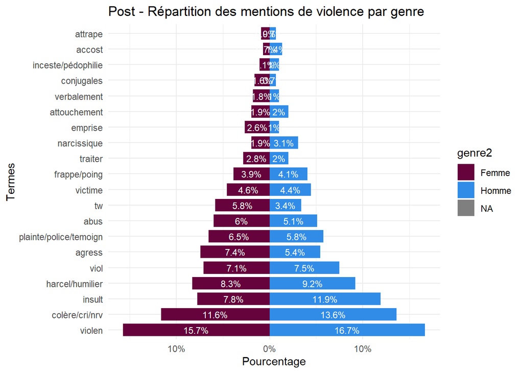

```r
# Apply to each term in comma-separated flags
vss_post_plus <- vss_post_plus %>%
  mutate(
    flag_group2 = map_chr(
      str_split(flag, ",\\s*"),
      ~ {
        mapped <- map_chr(.x, map_term_to_group)
        paste(unique(mapped), collapse = ", ")  # Remove duplicates
      }
    )
  )

#freq(vss_post_plus$flag_group2)

#mais ça crée une liste de termes groupés, du coup on les dégroupe en allant "WIDE" et en créant des variables dichotomique pour chacune des racines retenues

  vss_wide <- vss_post_plus %>%
    separate_rows(flag_group2, sep = ",\\s*") %>%
    filter(flag_group2 != "") %>%
    mutate(value = 1) %>%
    distinct(docid, flag_group2, .keep_all = TRUE) %>%
    pivot_wider(
      names_from = flag_group2,
      values_from = value,
      values_fill = 0,
      names_prefix = "flag_"
    )

  data_for_plot <- vss_wide %>%
      #mutate(genre2 = if_else(is.na(genre2), "Non spécifié", genre2)) %>%
    pivot_longer(
      cols = where(is.numeric) & starts_with("flag_"),
      names_to = "flag_words",
      values_to = "present"
    ) %>%
    # Remove the "flag_" prefix
    mutate(flag_words = str_remove(flag_words, "^flag_")) %>%

    # Keep only rows where flag is present
    filter(present == 1) %>%

    # Count how many times each flag appears for each genre2
    count(flag_words, genre2, name = "effectif") %>%

    # Calculate frequency within each genre2
    group_by(genre2) %>%
    mutate(
      total_in_genre2 = sum(effectif),
      frequence = effectif / total_in_genre2 * 100,
      pct = frequence,  # Alias for compatibility
      freq = ifelse(genre2 == "Femme", -frequence, frequence)  # For pyramid plot
    ) %>%
    ungroup()

  # testwtf <- vss_wide %>%
  #   filter(flag_viol == 1) %>%
  #   select(selftext, genre2, genre2_source, author, author_flair)

 # freq(testwtf$genre2)

  # Sort flags by total frequency
  flag_order <- data_for_plot %>%
    group_by(flag_words) %>%
    summarise(total = sum(effectif)) %>%
    arrange(desc(total)) %>%
    pull(flag_words)

  data_for_plot <- data_for_plot %>%
    mutate(flag_words = factor(flag_words, levels = flag_order))


  # Create pyramid plot
  ggplot(data_for_plot, aes(x = freq, y = flag_words, fill = genre2)) +
    geom_col(width = 0.8) +
    geom_text(
      aes(label = paste0(round(abs(freq), 1), "%")),
      position = position_stack(vjust = 0.5),
      size = 3,
      color = "white"
    ) +
    scale_x_continuous(labels = function(x) paste0(abs(x), "%")) +
    scale_fill_manual(values = c("Femme" = "#66023C", "Homme" = "#318CE7")) +
    labs(
      x = "Pourcentage",
      y = "Termes",
      title = "Post - Répartition des mentions de violence par genre"
    ) +
    theme_minimal()
```

Les écarts ne sont pas évidents, on passe donc en pourcentage en ligne, donc pour chaque terme la somme des pourcentage = 100%. On en profite pour rajouter les genre non spécifié.

#### 5.1.2 Représentation en pourcentage par termes

**Voir le code**

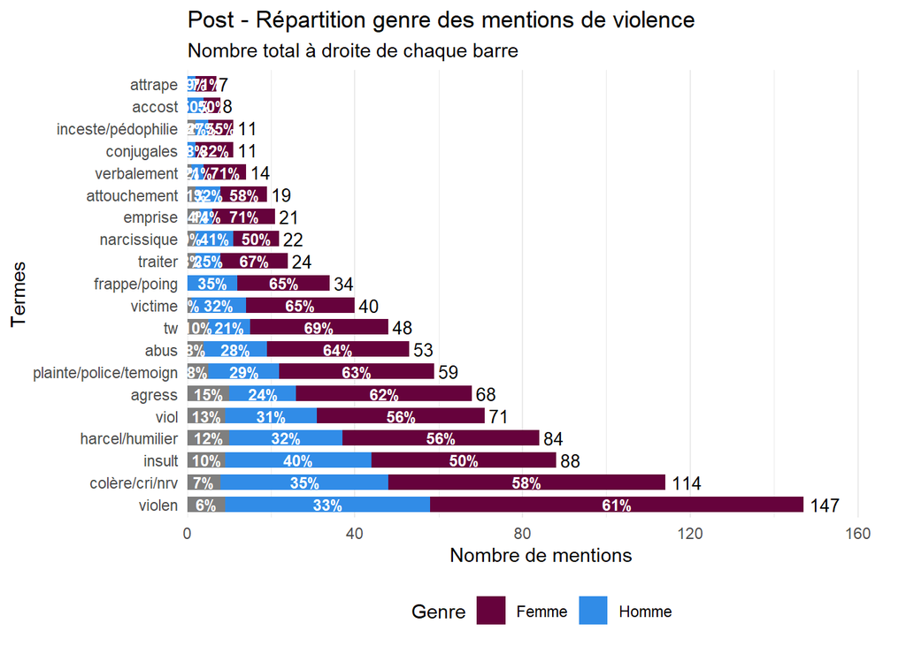

```r
# Option 1 (simplest) - Fixed
data_plot <- vss_wide %>%
        mutate(genre2 = if_else(is.na(genre2), "Non spécifié", genre2)) %>%
  pivot_longer(
    cols = where(is.numeric) & starts_with("flag_"),
    names_to = "flag_words",
    values_to = "present"
  ) %>%
  mutate(flag_words = str_remove(flag_words, "^flag_")) %>%
  filter(present == 1) %>%
  count(flag_words, genre2, name = "effectif") %>%
  group_by(flag_words) %>%
  mutate(
    total_term = sum(effectif),
    pct = effectif / total_term * 100,
    flag_label = paste0(flag_words, "\n(n=", total_term, ")")
  ) %>%
  ungroup()

  # Sort flags by total frequency
  flag_order <- data_plot %>%
    group_by(flag_words) %>%
    summarise(total = sum(effectif)) %>%
    arrange(desc(total)) %>%
    pull(flag_words)

data_plot <- data_plot %>%
    mutate(flag_words = factor(flag_words, levels = flag_order))
#
# # Get top terms
# top_terms <- data_plot %>%
#   group_by(flag_words) %>%
#   summarise(total = first(total_term)) %>%
#   arrange(desc(total)) %>%
#   slice_head(n = 15) %>%
#   pull(flag_words)
#
# data_plot <- data_plot %>%
#  # filter(flag_words %in% top_terms) %>%
#   mutate(
#     flag_words = factor(flag_words, levels = rev(top_terms)),
#     flag_label = factor(flag_label,
#                        levels = unique(flag_label[order(match(flag_words, rev(top_terms)))]))
#   )
# Create plot with effectif on the right
ggplot(data_plot, aes(x = effectif, y = flag_words, fill = genre2)) +
  geom_col(width = 0.7) +
  # Percentage labels inside bars
  geom_text(
    aes(label = paste0(round(pct, 0), "%")),
    position = position_stack(vjust = 0.5),
    color = "white",
    fontface = "bold",
    size = 3.2
  ) +
  # Total effectif on the right side - using separate data
  geom_text(
    data = data_plot %>%
      group_by(flag_words) %>%
      summarise(
        total = sum(effectif),
        .groups = 'drop'
      ),
    aes(x = total, y = flag_words, label = total),
    hjust = -0.2,  # Position to the right of the bar
    size = 3.5,
    color = "black",
    inherit.aes = FALSE  # Don't inherit fill aesthetic
  ) +
  scale_fill_manual(
    values = c("Femme" = "#66023C", "Homme" = "#318CE7"),
    name = "Genre"
  ) +
  scale_x_continuous(
    expand = expansion(mult = c(0, 0.15))  # Extra space on right for labels
  ) +
  labs(
    x = "Nombre de mentions",
    y = "Termes",
    title = "Post - Répartition genre des mentions de violence",
    subtitle = "Nombre total à droite de chaque barre"
  ) +
  theme_minimal() +
  theme(
    legend.position = "bottom",
    panel.grid.major.y = element_blank()
  )
```

### 5.2 Base commentaire stricte

On fait la même visualisation sur la base de commentaires contenant un terme du lexique !

**Voir le code**

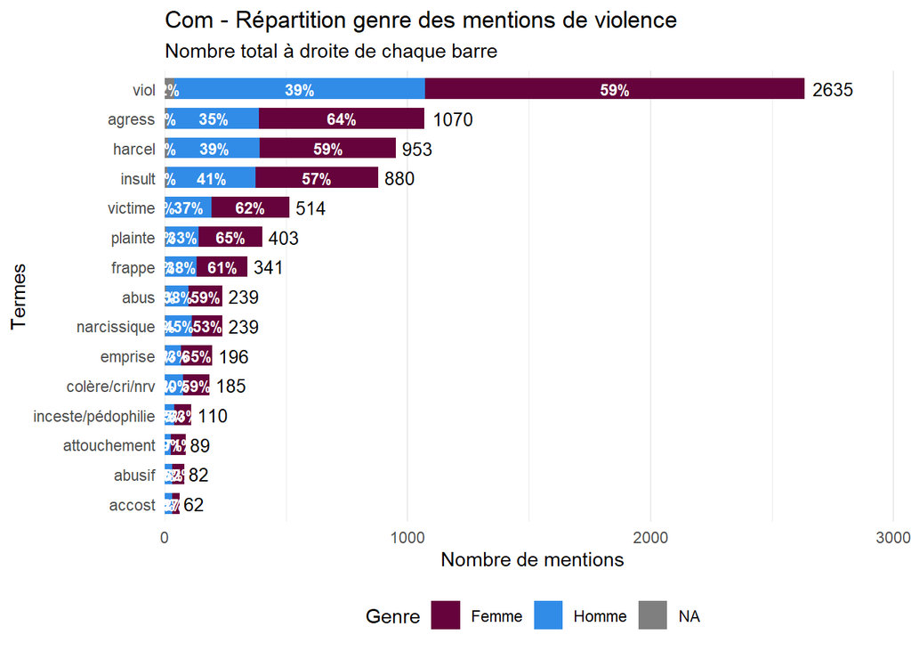

```r
#On groupe les mots flag avec les racines
vss_com_plus <- vss_com_plus %>%
  mutate(flag_group = wordStem(flag, language = "french")) %>%
  mutate(flag_group2 = case_when(str_detect(flag, "accoste|accoster")  ~ "accost",
                                 str_detect(flag, "attraper|attrape" )~ "attrape",
                                 str_detect(flag, "agresse|agresser|agression" )~ "agress",
                                 str_detect(flag, "attouchement|attouchements" )~ "attouchement",
                                 str_detect(flag, "colere|crier|enervement" )~ "colère/cri/nrv",
                                 str_detect(flag, "frappe|frapper" )~  "frappe",
                                 str_detect(flag, "harcele|harcelement|harceler" )~ "harcel",
                                 str_detect(flag, "inceste|pedophilie" )~ "inceste/pédophilie",
                                 str_detect(flag, "insultant|insultante|insulte|insulter|insultes")~ "insult",
                                 str_detect(flag, "viol|viole|violer")~ "viol",
                                 str_detect(flag, "violemment|violence|violence|violente|violences|violent|violente|violentometre" )~ "violen",
                                            TRUE ~ flag))

#
# # Define a function to map individual terms
# map_term_to_group <- function(term) {
#   case_when(
#     str_detect(term, regex("\\b(accoste|accoster)\\b", ignore_case = TRUE)) ~ "accost",
#     str_detect(term, regex("\\b(attraper|attrape)\\b", ignore_case = TRUE)) ~ "attrape",
#     str_detect(term, regex("\\b(agresse|agresser|agression)\\b", ignore_case = TRUE)) ~ "agress",
#     str_detect(term, regex("\\b(attouchement|attouchements)\\b", ignore_case = TRUE)) ~ "attouchement",
#     str_detect(term, regex("\\b(colere|crier|enervement)\\b", ignore_case = TRUE)) ~ "colère/cri/nrv",
#     str_detect(term, regex("\\b(frappe|frapper|poing)\\b", ignore_case = TRUE)) ~ "frappe/poing",
#         str_detect(term, regex("\\b(abusif|abusive)\\b", ignore_case = TRUE)) ~ "abusi",
#     str_detect(term, regex("\\b(harcele|harcelement|harceler|humilier)\\b", ignore_case = TRUE)) ~ "harcel/humilier",
#     str_detect(term, regex("\\b(inceste|pedophilie)\\b", ignore_case = TRUE)) ~ "inceste/pédophilie",
#     str_detect(term, regex("\\b(insultant|insultante|insulte|insulter|insultes)\\b", ignore_case = TRUE)) ~ "insult",
#     str_detect(term, regex("\\b(viol|viole|violer|rapport non consenti)\\b", ignore_case = TRUE)) ~ "viol",
#     str_detect(term, regex("\\b(violemment|violence|violences|violent|violente|violentometre)\\b", ignore_case = TRUE)) ~ "violen",
#     TRUE ~ term
#   )
# }


com_vss_wide <- vss_com_plus %>%
    separate_rows(flag_group2, sep = ",\\s*") %>%
    filter(flag_group2 != "") %>%
    mutate(value = 1) %>%
    distinct(docid, flag_group2, .keep_all = TRUE) %>%
    pivot_wider(
      names_from = flag_group2,
      values_from = value,
      values_fill = 0,
      names_prefix = "flag_"
    )
data_plot <- com_vss_wide %>%
  pivot_longer(
    cols = where(is.numeric) & starts_with("flag_"),
    names_to = "flag_words",
    values_to = "present"
  ) %>%
  mutate(flag_words = str_remove(flag_words, "^flag_")) %>%
  filter(present == 1) %>%
  count(flag_words, genre2, name = "effectif") %>%
  group_by(flag_words) %>%
  mutate(
    total_term = sum(effectif),
    pct = effectif / total_term * 100,
    flag_label = paste0(flag_words, "\n(n=", total_term, ")")
  ) %>%
  ungroup()

# Get top terms
top_terms <- data_plot %>%
  group_by(flag_words) %>%
  summarise(total = first(total_term)) %>%
  arrange(desc(total)) %>%
  slice_head(n = 15) %>%
  pull(flag_words)

data_plot <- data_plot %>%
  filter(flag_words %in% top_terms) %>%
  mutate(
    flag_words = factor(flag_words, levels = rev(top_terms)),
    flag_label = factor(flag_label,
                       levels = unique(flag_label[order(match(flag_words, rev(top_terms)))]))
  )
# Create plot with effectif on the right
ggplot(data_plot, aes(x = effectif, y = flag_words, fill = genre2)) +
  geom_col(width = 0.7) +
  # Percentage labels inside bars
  geom_text(
    aes(label = paste0(round(pct, 0), "%")),
    position = position_stack(vjust = 0.5),
    color = "white",
    fontface = "bold",
    size = 3.2
  ) +
  # Total effectif on the right side - using separate data
  geom_text(
    data = data_plot %>%
      group_by(flag_words) %>%
      summarise(
        total = sum(effectif),
        .groups = 'drop'
      ),
    aes(x = total, y = flag_words, label = total),
    hjust = -0.2,  # Position to the right of the bar
    size = 3.5,
    color = "black",
    inherit.aes = FALSE  # Don't inherit fill aesthetic
  ) +
  scale_fill_manual(
    values = c("Femme" = "#66023C", "Homme" = "#318CE7"),
    name = "Genre"
  ) +
  scale_x_continuous(
    expand = expansion(mult = c(0, 0.15))  # Extra space on right for labels
  ) +
  labs(
    x = "Nombre de mentions",
    y = "Termes",
    title = "Com - Répartition genre des mentions de violence",
    subtitle = "Nombre total à droite de chaque barre"
  ) +
  theme_minimal() +
  theme(
    legend.position = "bottom",
    panel.grid.major.y = element_blank()
  )
```

## 6 Croisement entre le genre de l’auteur.ice du post et celui des répondant.es

Pour rappel, le croisement du genre des auteurs de commentaires et des auteur.ices de posts auxquels ils répondent sur l’ensemble de la base de données.

### 6.1 Base complète - Croisement genre auteur.ices de commentaires x auteur.ices de posts

**Voir le code**

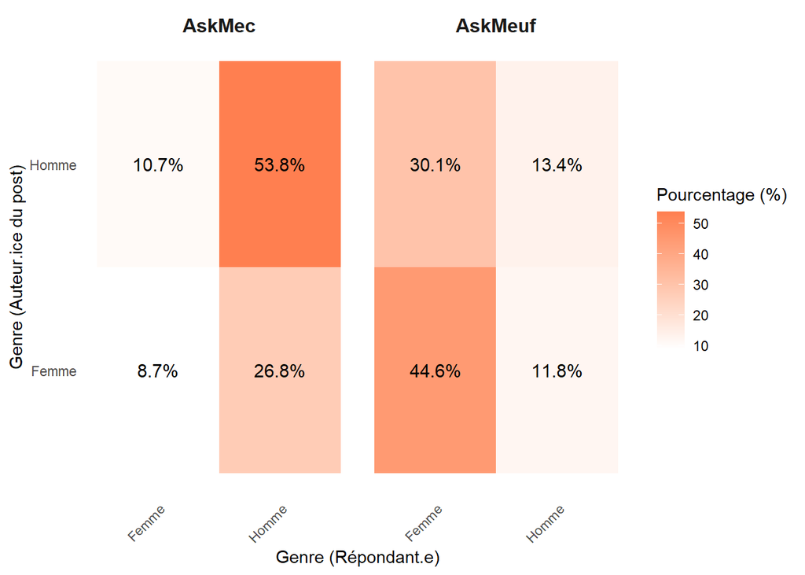

```r
cross_genre <- com %>%
  filter(!is.na(genre2) & !is.na(genre2_posteur)) %>%
  count(genre2, genre2_posteur, subreddit) %>%
  group_by(subreddit) %>%                  # Calculate % within each source × typo_label
  mutate(percent = n / sum(n) * 100) %>%
  ungroup()

ggplot(cross_genre, aes(x = genre2, y = genre2_posteur, fill = percent)) +
  geom_tile() +
  geom_text(aes(label = sprintf("%.1f%%", percent)), color = "black", size = 4) +
  facet_grid(. ~ subreddit) +                                                # Facet by source × typo_post
  scale_fill_gradient(low = "white", high = "#FF7F50", name = "Pourcentage (%)") +
  labs(x = "Genre (Répondant.e)",
       y = "Genre (Auteur.ice du post)"
  ) +
  theme_minimal() +
  theme(  strip.text = element_text(face = "bold", size = 12),
          axis.text.x = element_text(angle = 45, hjust = 1),
          panel.grid = element_blank())
```

### 6.2 Base com étendue - Croisement genre auteur.ices de commentaires x auteur.ices de posts

**Voir le code**

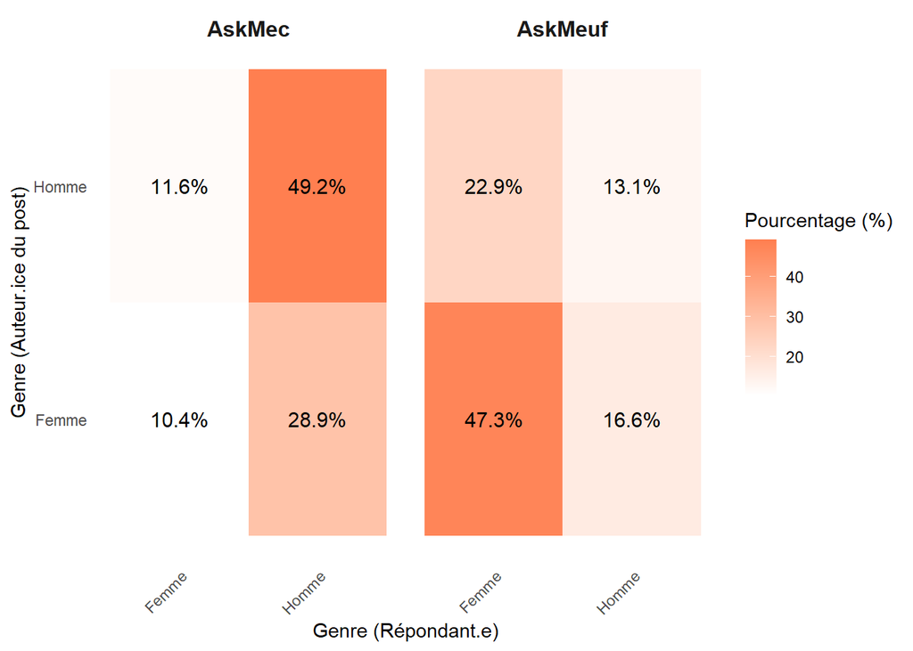

```r
cross_genre <- com_post_vss %>%
  filter(!is.na(genre2) & !is.na(genre2_posteur)) %>%
  count(genre2, genre2_posteur, subreddit) %>%
  group_by(subreddit) %>%                  # Calculate % within each source × typo_label
  mutate(percent = n / sum(n) * 100) %>%
  ungroup()

ggplot(cross_genre, aes(x = genre2, y = genre2_posteur, fill = percent)) +
  geom_tile() +
  geom_text(aes(label = sprintf("%.1f%%", percent)), color = "black", size = 4) +
  facet_grid(. ~ subreddit) +                                                # Facet by source × typo_post
  scale_fill_gradient(low = "white", high = "#FF7F50", name = "Pourcentage (%)") +
  labs(x = "Genre (Répondant.e)",
       y = "Genre (Auteur.ice du post)"
  ) +
  theme_minimal() +
  theme(  strip.text = element_text(face = "bold", size = 12),
          axis.text.x = element_text(angle = 45, hjust = 1),
          panel.grid = element_blank())
```

### 6.3 Base commentaires stricte - Croisement genre auteur.ices de commentaires x auteur.ices de posts

Ci-dessous, le genre des auteurices de commentaires comprenant un terme du lexique et celui auteur.ices des posts auxquels ces commentaires répondent (les na ne sont pas représentés, soit 796 commentaires sur 8073).

**Voir le code**

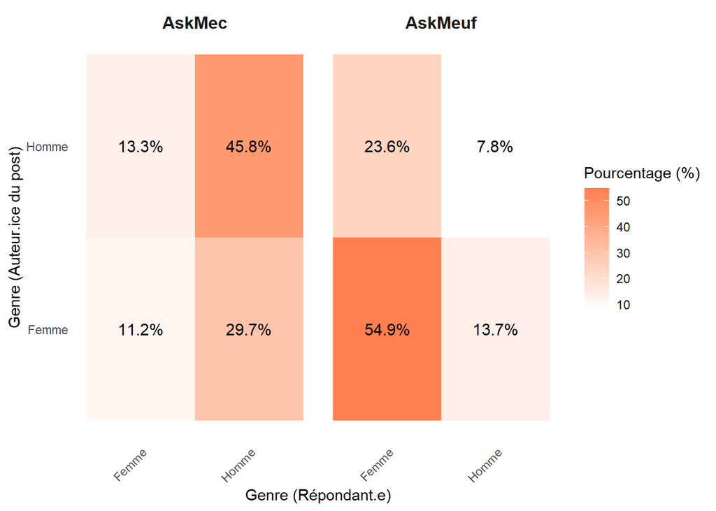

```r
cross_genre <- vss_com_plus %>%
  filter(!is.na(genre2) & !is.na(genre2_posteur)) %>%
  count(genre2, genre2_posteur, subreddit) %>%
  group_by(subreddit) %>%                  # Calculate % within each source × typo_label
  mutate(percent = n / sum(n) * 100) %>%
  ungroup()

ggplot(cross_genre, aes(x = genre2, y = genre2_posteur, fill = percent)) +
  geom_tile() +
  geom_text(aes(label = sprintf("%.1f%%", percent)), color = "black", size = 4) +
  facet_grid(. ~ subreddit) +                                                # Facet by source × typo_post
  scale_fill_gradient(low = "white", high = "#FF7F50", name = "Pourcentage (%)") +
  labs(x = "Genre (Répondant.e)",
       y = "Genre (Auteur.ice du post)"
  ) +
  theme_minimal() +
  theme(  strip.text = element_text(face = "bold", size = 12),
          axis.text.x = element_text(angle = 45, hjust = 1),
          panel.grid = element_blank())
```

### 6.4 Extension base de post - Croisement genre auteur.ices de commentaires x auteur.ices de posts

Sur les commentaires qui répondent à un post qui ne contient PAS de termes du lexique.

**Voir le code**

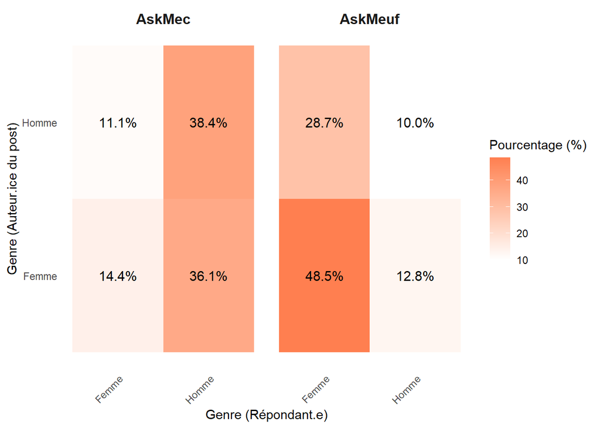

```r
cross_genre <- vss_com_plus %>%
  filter(clé %in% post_plusplus$links) %>%
  filter(!is.na(genre2) & !is.na(genre2_posteur)) %>%
  count(genre2, genre2_posteur, subreddit) %>%
  group_by(subreddit) %>%                  # Calculate % within each source × typo_label
  mutate(percent = n / sum(n) * 100) %>%
  ungroup()

ggplot(cross_genre, aes(x = genre2, y = genre2_posteur, fill = percent)) +
  geom_tile() +
  geom_text(aes(label = sprintf("%.1f%%", percent)), color = "black", size = 4) +
  facet_grid(. ~ subreddit) +                                                # Facet by source × typo_post
  scale_fill_gradient(low = "white", high = "#FF7F50", name = "Pourcentage (%)") +
  labs(x = "Genre (Répondant.e)",
       y = "Genre (Auteur.ice du post)"
  ) +
  theme_minimal() +
  theme(  strip.text = element_text(face = "bold", size = 12),
          axis.text.x = element_text(angle = 45, hjust = 1),
          panel.grid = element_blank())
```

Une baisse des interactions femme-femme ? Cela s’explique peut-être par le nombre d’homme auteur dans ce sous échantillon, dont on n’a pas fait la description.

**Voir le code**

```r
lul <- make_cross_table(
  post_plusplus, genre2, subreddit,
  percent = "cell",
  label = list(genre2 ~ "Genre", subreddit ~ "Subreddit"),
  filename = NULL
)

lul
```

|  | Subreddit AskMec | Subreddit AskMeuf | Total |
| --- | --- | --- | --- |
| Genre |  |  |  |
| Femme | 57 (17%) | 108 (32%) | 165 (49%) |
| Homme | 70 (21%) | 76 (23%) | 146 (43%) |
| Unknown | 6 (1.8%) | 19 (5.7%) | 25 (7.4%) |
| Total | 133 (40%) | 203 (60%) | 336 (100%) |

Test du khi-deux : p = 0.022

**Voir le code**

```r
post_plus_test <-  post_plusplus %>%
  filter(genre2 == "Homme") %>%
  sample_n(10) %>%
  select(selftext, com_scoremax,flag_com )

dt <- datatable(post_plus_test,
                options = list(
    pageLength = 5,           # Show 15 rows per page
    scrollX = TRUE,            # Horizontal scroll if needed
    scrollY = "400px"         # Fixed height with vertical scroll
  ),
  class = 'display compact',   # Compact styling
  rownames = FALSE             # Hide row numbers
)

dt
```

| selftext | com_scoremax | flag_com |
| --- | --- | --- |
| comment interpréter ses refus ? bonjour, j expose le contexte, moi h24 elle f30, on taffe dans la même boîte et sur le même projet depuis 6mois. depuis 4 mois on s est rapproché, sur teams on peut pas… | Parce qu'il existe des gens incapables d'accepter un non et finissent par t'insulter (ça m'est arrivé) | insulter |
| vous êtes (peut-être) suivie par un inconnu dans la rue, la nuit, comment vous réagissez ? contexte : [ (hyperlien) | M'est déjà arrivé d'avoir l'impression d'être suivie (je pense que c'était pas le cas mais on sait jamais), si la personne est vraiment proche je me met sur le coté et je fais mon lacet ou je check un… | agresser |
| une fille veut tromper son copain avec moi, comment savoir si elle compte le dire à son copain après coup ou pas? son copain est flic donc j aimerais éviter qu il vienne me casser la figure. ou d avoi… | Pour quelqu'un qui a 32 ans, tu n'as pas l'air d'avoir beaucoup de jugeote. Et puis j'imagine qu'elle doit l'avoir en ami sur des réseaux sociaux son copain, tu pourrais essayer de le retrouver comme … | harcele |
| est ce un red flag ? je suis en couple avec ma copine depuis deux mois maintenant. et récemment, elle m a demandé si elle était la plus belle femme au monde. ce à quoi j ai répondu oui. malheureusemen… | Ce genre de comportement ça passe à 16 ans après c'est chaud =''Oui gros, redflag immature + narcissique | narcissique |
| quelle méthode vous rassure le plus quand un mec marche derrière vous la nuit dans la rue ? en en parlant avec des potes je me rends compte qu on sait pas trop quoi faire pour pas faire peur à une fem… | Desole mais tes propos minterpellent bcp, jaimerais comprendre. ''Donc du fait quon est pas responsable du problème, on doit surtout ne rien faire pour aider la dessus ?''Tu réalises jusqu'où peut all… | victime |
| première fois que je vis ça, et je ne sais pas comment réagir hey ho, j ai vraiment besoin de vos conseils sur un truc. j explique la situation (h27), j ai match avec une femme sur une appli (f31). el… | Hey OP, Hey la modération, je suis pas un mec mais une meuf trans. J'espérais pouvoir apporter ma réponse mais soyez libre de supp cette réponse si elle n'est pas conforme aux règles du sub. ''Hey OP … | violence |
| quel genre de compliment aimer vous dans la rue ou le supermarché les filles? salut a toutes et tous, je suis m40 et j ai croisé une femme dans un magasin, qui est vraiment mon style physiquement à 10… | La seule fois de ma vie où j'ai décidé d'accorder le bénéfice du doute à un mec qui m'avait abordée dans la rue, j'ai accepté un date et le moment le plus marquant de la soirée c'est quand il m'a mena… | harcelement |
| est-ce que ça a du sens de pardonner une infidélité ? bonjour, mon copain (m28) m a appris samedi qu il m avait trompé jeudi soir à une soirée. il était chez un ami qu on a en commun et a dansé avec u… | Je pense qu'un élément essentiel pour bien saisir notre situation est de comprendre que ni lui, ni moi, ne considérons l'infidélité comme une sorte de péché capital ou de tabou/trahison ultime qui rem… | victime |
| quelles sont les choses qui vous font sentir réellement homme ? des situations, des moments, etc. ça peut être n importe quoi tant que ça fait vous dire « ouais je suis vraiment un mec » | Quand je dis "bonjour mademoiselle" à une femme en étant bourré et qu'elle appelle la police pour venir m'arrêter au nom du harcèlement de rue. | harcelement |
| mon mec rejoint un groupe de personnes que je n aime pas et qui ne m aiment pas contexte : je (f35) suis en couple avec mon conjoint (h32) depuis 5 ans. tout se passe globalement bien jusqu à ce qu il… | (M33) On est dans un village donc je suppose que le comité est assez restreint (peu de personnes doivent le composer). Si j'apprends que dans le comité il y a des gens qui ont manqué de respect/harcel… | harcele |

### 6.5 Bonus : Répartition de la provenance des posts de la base étendu en fonction des termes

Pas très utile, mais montre que le termes victime et plainte ramène pas mal de post, à voir si on les gardes ou non ! Pour l’instant les posts sélectionnés par cette méthode ont l’air pertinents.

**Voir le code**

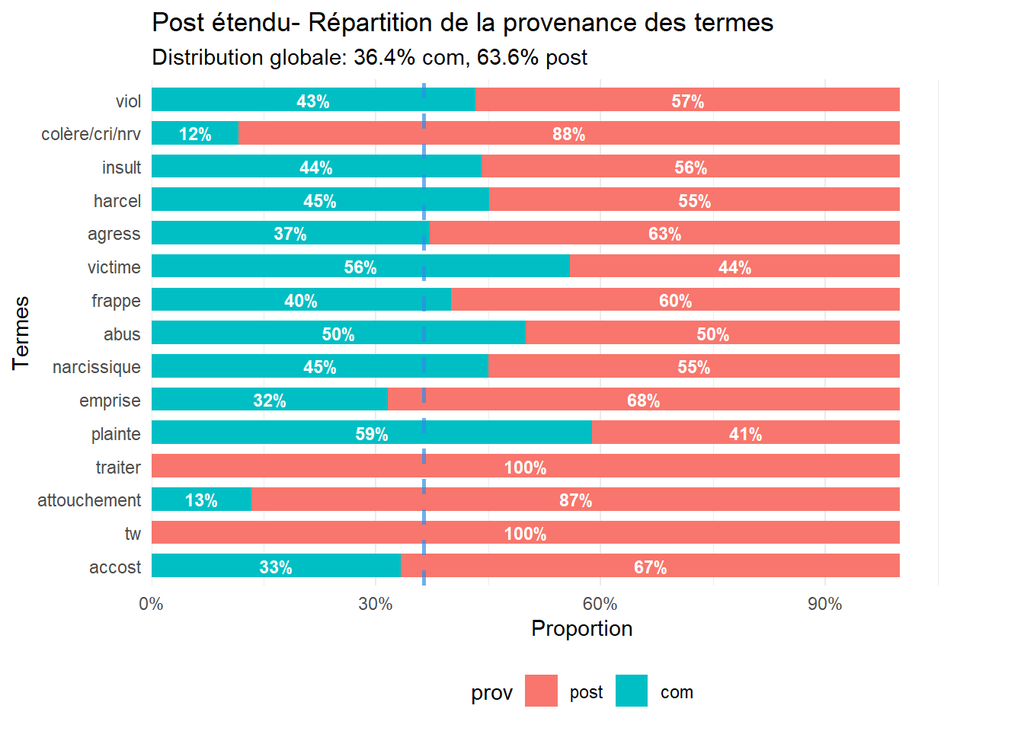

```r
# Option 1 (simplest) - Fixed
#On groupe les mots flag avec les racines
# Option 1 (simplest) - Fixed
#On groupe les mots flag avec les racines
post_vss <- post_vss %>%
  mutate(flag_group = wordStem(flag, language = "french")) %>%
  mutate(flag2 = case_when(
    flag == "com flag" ~ flag_com,  # Use flag_com for "com flag"
    TRUE ~ flag  # Use original flag for everything else
  )) %>%
  mutate(flag_group2 = case_when(str_detect(flag2, "accoste|accoster")  ~ "accost",
                                 str_detect(flag2, "attraper|attrape" )~ "attrape",
                                 str_detect(flag2, "agresse|agresser|agression" )~ "agress",
                                 str_detect(flag2, "attouchement|attouchements" )~ "attouchement",
                                 str_detect(flag2, "colere|crier|enervement" )~ "colère/cri/nrv",
                                 str_detect(flag2, "frappe|frapper" )~  "frappe",
                                 str_detect(flag2, "harcele|harcelement|harceler" )~ "harcel",
                                 str_detect(flag2, "inceste|pedophilie" )~ "inceste/pédophilie",
                                 str_detect(flag2, "insultant|insultante|insulte|insulter|insultes")~ "insult",
                                 str_detect(flag2, "viol|viole|violer")~ "viol",
                                 str_detect(flag2, "violemment|violence|violence|violente|violences|violent|violente|violentometre" )~ "violen",
                                 TRUE ~ flag2))

vss_wide <- post_vss %>%
  separate_rows(flag_group2, sep = ",\\s*") %>%
  filter(flag_group2 != "") %>%
  mutate(value = 1) %>%
  distinct(docid, flag_group2, .keep_all = TRUE) %>%
  pivot_wider(
    names_from = flag_group2,
    values_from = value,
    values_fill = 0,
    names_prefix = "flag_"
  )

# Calculate overall distribution of prov in the dataset - AFTER creating vss_wide
overall_dist <- vss_wide %>%
  summarise(
    com_pct = sum(prov == "com") / n() * 100,
    post_pct = sum(prov == "post") / n() * 100
  )

# Create the plot data with percentages
data_plot <- vss_wide %>%
  pivot_longer(
    cols = where(is.numeric) & starts_with("flag_"),
    names_to = "flag_words",
    values_to = "present"
  ) %>%
  mutate(flag_words = str_remove(flag_words, "^flag_")) %>%
  filter(present == 1) %>%
  count(flag_words, prov, name = "effectif") %>%
  group_by(flag_words) %>%
  mutate(
    total_term = sum(effectif),
    pct = effectif / total_term * 100,
    flag_label = paste0(flag_words, "\n(n=", total_term, ")")
  ) %>%
  ungroup()

# Get top terms
top_terms <- data_plot %>%
  group_by(flag_words) %>%
  summarise(total = first(total_term)) %>%
  arrange(desc(total)) %>%
  slice_head(n = 15) %>%
  pull(flag_words)

data_plot <- data_plot %>%
  filter(flag_words %in% top_terms) %>%
  mutate(
    flag_words = factor(flag_words, levels = rev(top_terms)),
    flag_label = factor(flag_label,
                        levels = unique(flag_label[order(match(flag_words, rev(top_terms)))]))
  )

data_plot <- data_plot %>%
  mutate(prov = fct_relevel(prov,
                            "post",
                            "com"))
ggplot(data_plot, aes(x = pct, y = flag_words, fill = prov)) +
  geom_col(position = "fill", width = 0.7) +
  geom_vline(xintercept = overall_dist$com_pct/100,
             color = "#318CE7",
             linetype = "dashed",
             linewidth = 1,
             alpha = 0.7) +

  geom_text(
    aes(label = paste0(round(pct, 0), "%")),
    position = position_fill(vjust = 0.5),
    color = "white",
    fontface = "bold",
    size = 3.2
  ) +
  scale_x_continuous(
    labels = scales::percent_format(),
    expand = expansion(mult = c(0, 0.15))
  ) +
  labs(
    x = "Proportion",
    y = "Termes",
    title = "Post étendu- Répartition de la provenance des termes",
    subtitle = paste0("Distribution globale: ",
                      round(overall_dist$com_pct, 1), "% com, ",
                      round(overall_dist$post_pct, 1), "% post")
  ) +
  theme_minimal() +
  theme(
    legend.position = "bottom",
    panel.grid.major.y = element_blank()
  )
```

Pour la suite : un graphique des coocurences des termes sélectionnés type https://slcladal.netlify.app/coll.html#3_Visualizing_Collocations ? Prendre le temps de lire de façon plus quali ce qu’on a sélectionné ? Chercher les posts “Témoignage ?”